# D.C. Dollars & Data

### MATH 014 – Introduction to Data Science

### Spring 2026

## 1. Introduction

This project analyzes the DC Public Employee Salary dataset from DC Open Data.This dataset includes employee information such as job title, department, grade, compensation rate, hire date, and appointment type. I picked this dataset because I wanted to look at how pay differs across departments and job positions in DC government, as well as learning about new departments I can use my study in. This was a school project but also an educational personal research project for me.

## 2. Objective and Research Questions

The goal of this project is to explore salary patterns in the DC government data. I also want to use this to learn more about what kind of positions or departments might be good for my own career path.

## 3. Import Libraries

```python
import pandas as pd
import numpy as np
import matplotlib.pyplot as plt
import seaborn as sns
```

## 4. Data Loading

```python
df = pd.read_csv("salary.csv")
```

```python
df.head()
```

|  | FIRST_NAME | LAST_NAME | JOBTITLE | DESCRSHORT | GRADE | COMPRATE | HIREDATE_STRING | GVT_TYPE_OF_APPT | OBJECTID |
| --- | --- | --- | --- | --- | --- | --- | --- | --- | --- |
| 0 | Natasha | Boley | Compliance Specialist | DBH | 13 | 123873.00 | 2004/10/18 | CS - Reg | 1 |
| 1 | Korlu | Wolobah-Kuyon | PSYCHIATRIC NURSE | DBH | 09 | 115907.00 | 2020/08/17 | CS - Reg | 2 |
| 2 | Hadizat | Elayo-Ross | SUPERVISORY PSYCHIATRIC NURSE | DBH | 13 | 122500.00 | 2023/08/14 | MSS - Reg | 3 |
| 3 | Gary | Evans | Climate Control Maint Mechanic | DBH | 11 | 41.73 | 1985/08/27 | CS - Reg | 4 |
| 4 | Jemia | Gross | Special Police Officer | DBH | 08 | 75787.00 | 2016/11/14 | CS - Reg | 5 |

## 5. Data Understanding

##### In this section, I examined the dataset to see what it contains. I looked at the shape, columns, and data types. I also used `df.info()` to get a quick summary of the columns and non-null counts, as well as `df.describe()` to see the summary statistics for the numerical columns like compensation. I learned about these new functions at W3Schools.

#### Check the shape of the data

```python
print("Data shape:", df.shape)
```

```
Data shape: (40611, 9)
```

#### Get column names

```python
print("Columns:", df.columns)
```

```
Columns: Index(['FIRST_NAME', 'LAST_NAME', 'JOBTITLE', 'DESCRSHORT', 'GRADE',
       'COMPRATE', 'HIREDATE_STRING', 'GVT_TYPE_OF_APPT', 'OBJECTID'],
      dtype='object')
```

#### Get info about the data types and nulls

```python
df.info()
```

```
<class 'pandas.core.frame.DataFrame'>
RangeIndex: 40611 entries, 0 to 40610
Data columns (total 9 columns):
 #   Column            Non-Null Count  Dtype
---  ------            --------------  -----
 0   FIRST_NAME        40611 non-null  object
 1   LAST_NAME         40611 non-null  object
 2   JOBTITLE          40611 non-null  object
 3   DESCRSHORT        40611 non-null  object
 4   GRADE             40571 non-null  object
 5   COMPRATE          40611 non-null  float64
 6   HIREDATE_STRING   40611 non-null  object
 7   GVT_TYPE_OF_APPT  40611 non-null  object
 8   OBJECTID          40611 non-null  int64
dtypes: float64(1), int64(1), object(7)
memory usage: 2.8+ MB
```

#### Summary statistics for numerical columns

```python
df.describe()
```

|  | COMPRATE | OBJECTID |
| --- | --- | --- |
| count | 40611.000000 | 40611.000000 |
| mean | 89087.755572 | 20306.000000 |
| std | 47453.788915 | 11723.530228 |
| min | 0.030000 | 1.000000 |
| 25% | 66130.000000 | 10153.500000 |
| 50% | 93234.000000 | 20306.000000 |
| 75% | 119643.130000 | 30458.500000 |
| max | 390232.000000 | 40611.000000 |

## 6. Data Cleaning

#### Standardize column names to be uppercase

```python
df.columns = df.columns.str.strip().str.upper()
```

#### Fill missing grades with *Unknown*

```python
df["GRADE"] = df["GRADE"].fillna("Unknown")
```

#### Convert hire date to datetime objects

```python
df["HIREDATE_STRING"] = pd.to_datetime(df["HIREDATE_STRING"], format="%Y%m%d", errors="coerce")
```

#### Check if there are any duplicate rows

```python
duplicates = df.duplicated().sum()
```

```python
print(f"Number of duplicate rows: {duplicates}")
```

```
Number of duplicate rows: 0
```

#### Check the results

```python
df.head()
```

[output not shown]

```python
df.columns
```

[output not shown]

## 6. Exploratory Data Analysis

##### Now that the data is clean, I want to see what it actually shows. I’ll look at the average pay, the most common jobs, and how pay is spread out across different departments. This helps me get a better idea of what to graph later.

#### Look at the salary numbers

```python
df["COMPRATE"].describe()
```

```
count     40611.000000
mean      89087.755572
std       47453.788915
min           0.030000
25%       66130.000000
50%       93234.000000
75%      119643.130000
max      390232.000000
Name: COMPRATE, dtype: float64
```

#### Count how many people are in each department

```python
df["DESCRSHORT"].value_counts().head(10)
```

```
DESCRSHORT
DCPS        11764
MPD          4123
FEMS         2366
UDC          1716
DPW          1480
OCFO         1386
DBH          1248
DDOT         1212
DHS          1182
OSSE DOT     1177
Name: count, dtype: int64
```

#### Find the average pay for each department

```python
df.groupby("DESCRSHORT")["COMPRATE"].mean().sort_values(ascending=False).head(10)
```

```
DESCRSHORT
CJDT     187500.000000
MOLC     163643.803000
OSA      153089.606000
OEA      151215.122500
CAB      146127.447273
DCA      142048.751852
PSC      139088.642000
RHC      138841.731429
OCA      137245.592909
OLRCB    128807.598750
Name: COMPRATE, dtype: float64
```

#### Check how many employees are in each appointment type

```python
df["GVT_TYPE_OF_APPT"].value_counts()
```

```
GVT_TYPE_OF_APPT
CS - Reg      19794
Ed - Reg      12311
MSS - Reg      2516
CS - Term      2078
Ed - Temp      1913
LS - Reg        602
ExS - Reg       566
CS - Temp       522
LS - Term        69
Ed - Term        62
Exe - Reg        61
MSS - Temp       36
MSS - Term       28
ExS - Term       20
ExS - Temp       16
Acting            9
Exe - Term        5
Exe - Temp        3
Name: count, dtype: int64
```

#### See average pay by appointment type

```python
df.groupby("GVT_TYPE_OF_APPT")["COMPRATE"].mean()
```

```
GVT_TYPE_OF_APPT
Acting        102457.111111
CS - Reg       92897.597483
CS - Temp      23203.458716
CS - Term      75540.082199
Ed - Reg       86928.282438
Ed - Temp       7231.934715
Ed - Term      71697.482097
ExS - Reg     130373.117862
ExS - Temp     49796.822500
ExS - Term    118883.442500
Exe - Reg     211817.718197
Exe - Temp    114867.666667
Exe - Term    138187.536000
LS - Reg      159214.535631
LS - Term     114350.956522
MSS - Reg     126638.657107
MSS - Temp    134044.482500
MSS - Term     91404.045714
Name: COMPRATE, dtype: float64
```

## 7. Data Visualization and Interpretation

### Visualization 1: Distribution of Compensation Rates

**Intent:** I made this histogram to see how compensation rates are spread out across employees.

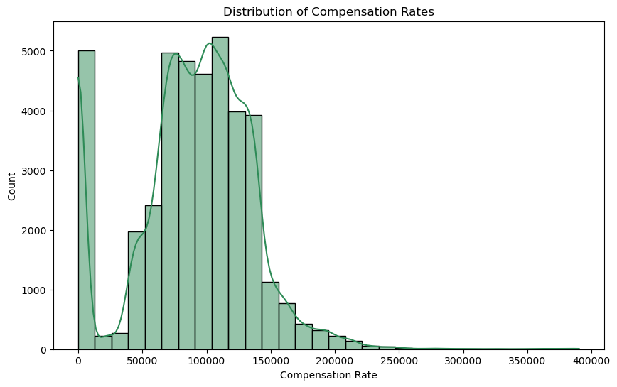

```python
plt.figure(figsize=(10,6))
sns.histplot(df["COMPRATE"], bins=30, kde=True, color="seagreen")
plt.title("Distribution of Compensation Rates")
plt.xlabel("Compensation Rate")
plt.ylabel("Count")
plt.show()
```

**Interpretation:** Most employees fall in the middle pay range, while fewer employees have very high compensation rates.

### Visualization 2: Top 10 Departments by Average Compensation

**Intent:** This bar chart compares the average pay across the top departments.

```python
top_depts = df.groupby("DESCRSHORT")["COMPRATE"].mean().sort_values(ascending=False).head(10)
```

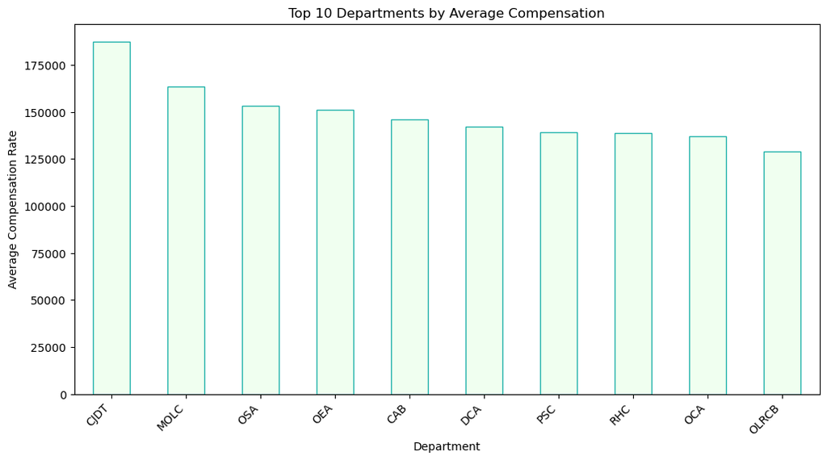

```python
plt.figure(figsize=(12,6))
top_depts.plot(kind="bar", color="honeydew", edgecolor="lightseagreen")
plt.title("Top 10 Departments by Average Compensation")
plt.xlabel("Department")
plt.ylabel("Average Compensation Rate")
plt.xticks(rotation=45, ha="right")
plt.show()
```

**Interpretation:** This graph shows that some departments have higher average compensation than others. It looks like a few departments stand out with noticeably higher pay, while the rest are a little lower. These differences may be because of specialized roles, seniority levels, or budget differences across departments.

### Visualization 3: Compensation by Appointment Type

**Intent:** This box plot was made to compare compensation across various appointment types and to see which ones have higher pay or more spread in pay.

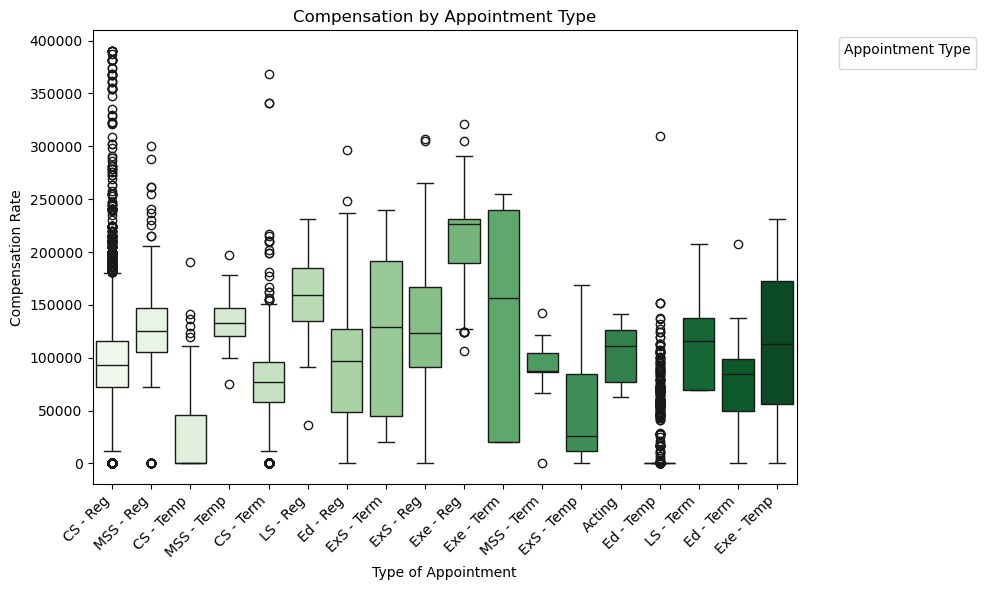

```python
plt.figure(figsize=(10,6))
sns.boxplot(
    data=df,
    x="GVT_TYPE_OF_APPT",
    y="COMPRATE",
    hue="GVT_TYPE_OF_APPT",
    dodge=False,
    palette="Greens"
)
plt.title("Compensation by Appointment Type")
plt.xlabel("Type of Appointment")
plt.ylabel("Compensation Rate")
plt.xticks(rotation=45, ha="right")
plt.legend(title="Appointment Type", bbox_to_anchor=(1.05, 1), loc="upper left")
plt.tight_layout()
plt.show()
```

**Interpretation:** This chart shows that some appointment types have higher pay than others, and a few of them have a lot more variation. I also noticed there are several outliers, which means some employees get paid much more than the rest in the same category.

### Visualization 4: Top 10 Job Titles by Average Compensation

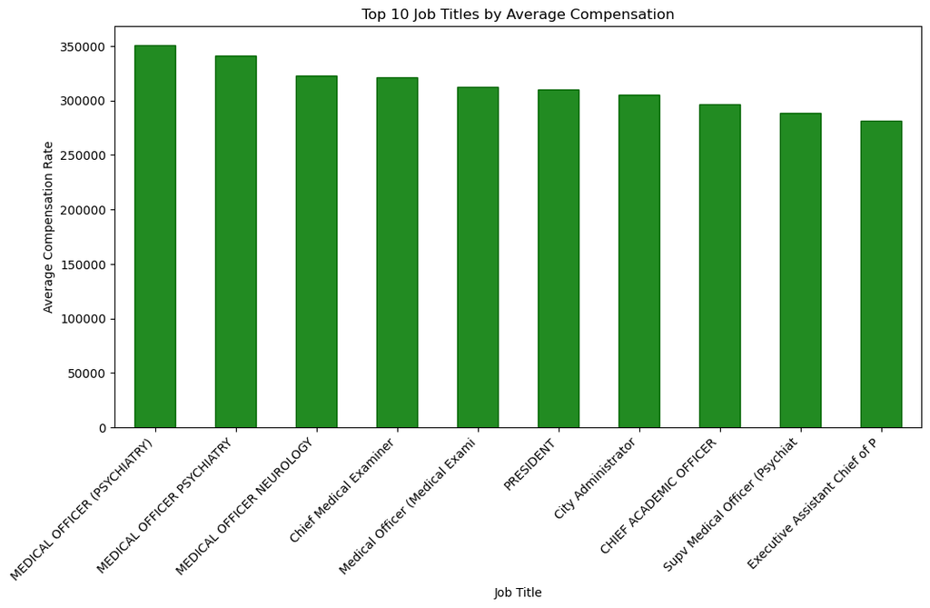

```python
top_jobs = df.groupby("JOBTITLE")["COMPRATE"].mean().sort_values(ascending=False).head(10)

plt.figure(figsize=(12,6))
top_jobs.plot(kind="bar", color="forestgreen", edgecolor="darkgreen")
plt.title("Top 10 Job Titles by Average Compensation")
plt.xlabel("Job Title")
plt.ylabel("Average Compensation Rate")
plt.xticks(rotation=45, ha="right")
plt.show()
```

### Visualization 5: Grade Frequency

**Intent:** This bar chart shows the most common employee grades in the dataset and helps describe the workforce structure.

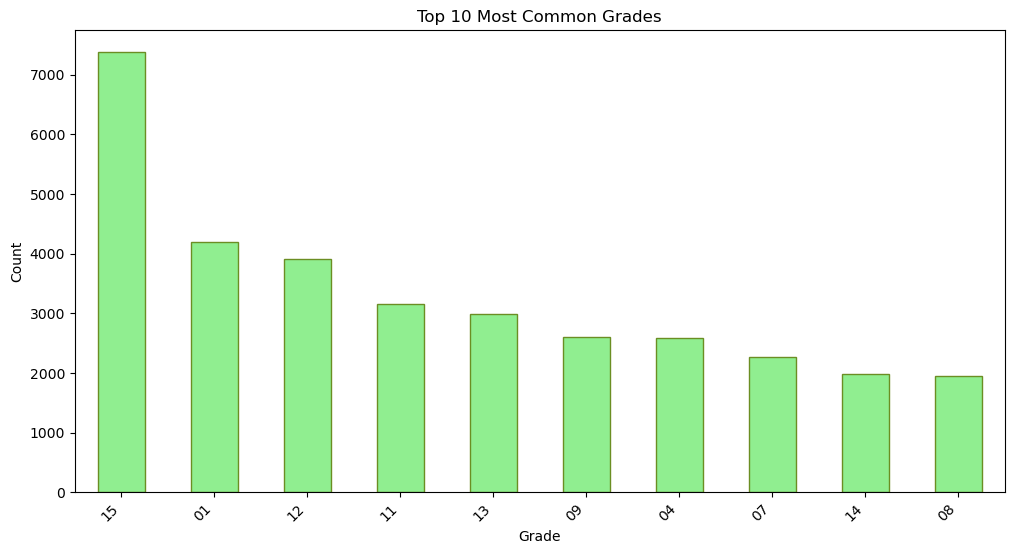

```python
plt.figure(figsize=(12,6))
df["GRADE"].value_counts().head(10).plot(kind="bar", color="lightgreen", edgecolor="olivedrab")
plt.title("Top 10 Most Common Grades")
plt.xlabel("Grade")
plt.ylabel("Count")
plt.xticks(rotation=45, ha="right")
plt.show()
```

**Interpretation:** This graph identifies some grades appear much more often than others. That suggests the workforce is concentrated more heavily in certain grade levels.

### Visualization 6: Salary Outliers by Department

**Intent:** This box plot compares compensation distributions across the most common departments and highlights outliers.

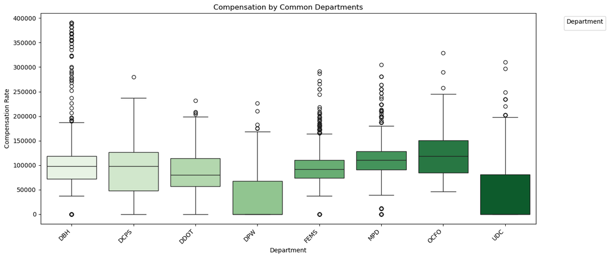

```python
top_common_depts = df["DESCRSHORT"].value_counts().head(8).index
filtered_df = df[df["DESCRSHORT"].isin(top_common_depts)]

plt.figure(figsize=(14,6))
sns.boxplot(
    data=filtered_df,
    x="DESCRSHORT",
    y="COMPRATE",
    hue="DESCRSHORT",
    dodge=False,
    palette="Greens"
)

plt.title("Compensation by Common Departments")
plt.xlabel("Department")
plt.ylabel("Compensation Rate")
plt.xticks(rotation=45, ha="right")
plt.legend(title="Department", bbox_to_anchor=(1.05, 1), loc="upper left")
plt.tight_layout()
plt.show()
```

**Interpretation:** This plot shows that some departments have more outliers than others. That means a few employees in those departments earn much more or much less than the typical salary in that group.

### Visualization 7: Interactive - Average Compensation by Department

**Intent:** This interactive chart was made to compare average compensation across departments in a way that is easier to explore.

```python
import plotly.express as px
```

```python
top_depts_df = (
    df.groupby("DESCRSHORT")["COMPRATE"]
    .mean()
    .sort_values(ascending=False)
    .head(10)
    .reset_index()
)
```

```python
fig = px.bar(
    top_depts_df,
    x="DESCRSHORT",
    y="COMPRATE",
    title="Interactive Chart: Top 10 Departments by Average Compensation",
    labels={"DESCRSHORT": "Department", "COMPRATE": "Average Compensation Rate"},
    color="COMPRATE",
    color_continuous_scale="greens",
    hover_data={"DESCRSHORT": True, "COMPRATE": ":.2f"}
)

fig.show()
```

[output not shown]

## 8. Additional Analysis / Findings

### Additional Analysis 1: Interactive - Average Compensation in Technology-Related Departments

This analysis compares average compensation in departments that are more related to technology, data, and systems work. The graph shows that compensation is not the same across technology-related departments. It helps connect the dataset to career areas that are more relevant to my interests in CIS, data science, and cybersecurity.

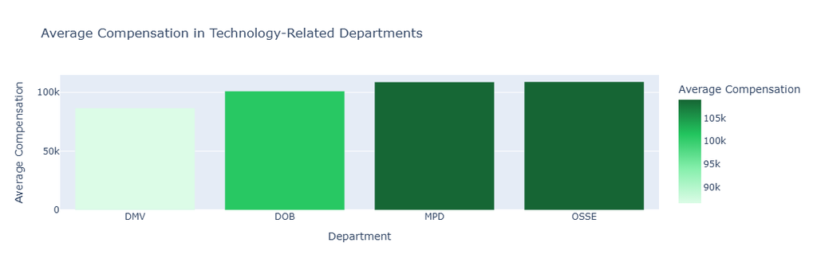

```python
focus_departments = ["DOB", "DMV", "MPD", "OSSE"]
focus_df = df[df["DESCRSHORT"].isin(focus_departments)]

avg_comp = focus_df.groupby("DESCRSHORT")["COMPRATE"].mean().reset_index()

fig = px.bar(
    avg_comp,
    x="DESCRSHORT",
    y="COMPRATE",
    title="Average Compensation in Technology-Related Departments",
    labels={"DESCRSHORT": "Department", "COMPRATE": "Average Compensation"},
    color="COMPRATE",
    color_continuous_scale=["#dcfce7", "#86efac", "#22c55e", "#166534"]
)

fig.show()
```

### Additional Analysis 2: Median Compensation by Department

This analysis compares median compensation by department to get a more balanced view of pay across departments. This graph shows that some departments still have higher typical pay even when extreme values are reduced. Using the median makes it easier to compare departments without high outliers affecting the results as much.

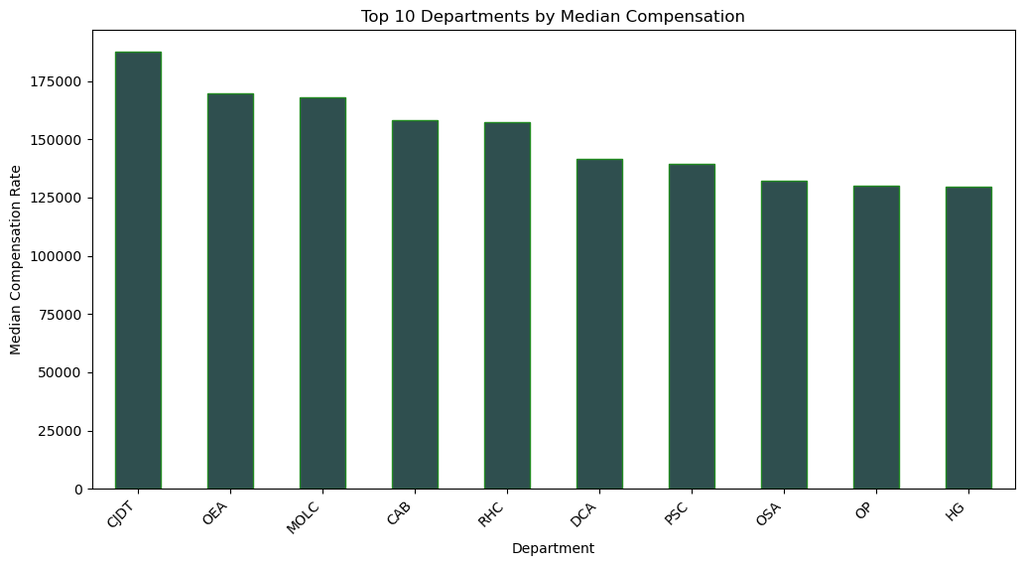

```python
dept_median = df.groupby("DESCRSHORT")["COMPRATE"].median().sort_values(ascending=False).head(10)

plt.figure(figsize=(12,6))
dept_median.plot(kind="bar", color="darkslategrey", edgecolor="forestgreen")
plt.title("Top 10 Departments by Median Compensation")
plt.xlabel("Department")
plt.ylabel("Median Compensation Rate")
plt.xticks(rotation=45, ha="right")
plt.show()
```

## 9. Insights and Conclusion

One limitation of this dataset is that it does not explain every reason behind salary differences. Important factors such as education, years of experience, overtime, and department-specific pay structures may not be fully captured. Future analysis could look more closely at how length of service or department-level trends relate to employee compensation.

```python
df.to_csv('Naimah_Muhammed_finalproject.csv', index=False)
```